# Machine Learning for Social Scientists, Part 1: Supervised ML - Ridge, Lasso, and Elastic Net

Author

Heeyoung Lee

Published

August 15, 2026

## Machine Learning for Social Scientists, Part 1

Every quantitative researcher eventually asks the same question: “Should I trust the coefficient, or should I trust the prediction?” Classical statistics and machine learning give different answers, and understanding *why* they differ is the single most useful thing you can learn before touching a machine learning method. This post covers three foundational ideas — supervised vs. unsupervised learning, the bias-variance tradeoff, and the logic of regularization — using the same county-level health framing from the panel data post, so the intuition carries over.

Let’s begin by loading the packages we’ll need:

```r
library(dplyr)
library(ggplot2)
library(kableExtra)
library(patchwork)
library(glmnet)     # For lasso and ridge regression
library(tidyr)
```

### 1. Two Basic Flavors: Supervised vs. Unsupervised Learning

Before we get into bias, variance, and penalties, it helps to sort machine learning methods into two big buckets. Almost everything you’ll hear about — lasso, ridge, decision trees, random forests, clustering, topic models — falls into one of these two categories, and knowing which bucket you’re in tells you what kind of question you can even ask.

**The one-sentence version: does your data have an “answer key” or not?**

- **Supervised learning** — you have a known outcome you’re trying to predict. Every county in your data has both the predictors *and* the actual mortality rate attached to it. The algorithm learns by comparing its guesses to the real answer, the way a student learns from a teacher who grades their homework.
- **Unsupervised learning** — there is no known outcome. You just have a pile of county characteristics, and you’re asking the algorithm to find structure or patterns in it on its own — no teacher, no answer key, no grading.

#### 1-1. A Health Example of Each

Let’s stick with our running county mortality example and see how the same dataset supports both kinds of tasks.

**Supervised task**: “Using each county’s poverty rate, uninsured rate, obesity rate, and physician density, predict its mortality rate.” Here, mortality rate is the known outcome (the “label”) sitting right there in the data for every county we’ve already observed. The whole point of the exercise is to get better and better at guessing it. This is exactly the kind of task that lasso, ridge, decision trees, and random forests are built for — everything covered in the rest of this post, and in most of what people mean by “machine learning” in applied research.

**Unsupervised task**: “Group the 3,000 U.S. counties into a handful of health profiles, based on their poverty rate, obesity rate, opioid prescribing rate, and rural/urban status — without telling the algorithm what the groups should look like.” There’s no “correct” grouping to check against. The algorithm (e.g., cluster analysis) just looks for counties that resemble each other and sorts them into groups. You might end up with something like “high-poverty rural counties with elevated opioid prescribing,” “urban counties with high obesity but strong healthcare access,” and so on — categories nobody specified in advance, but that emerged from the data itself.

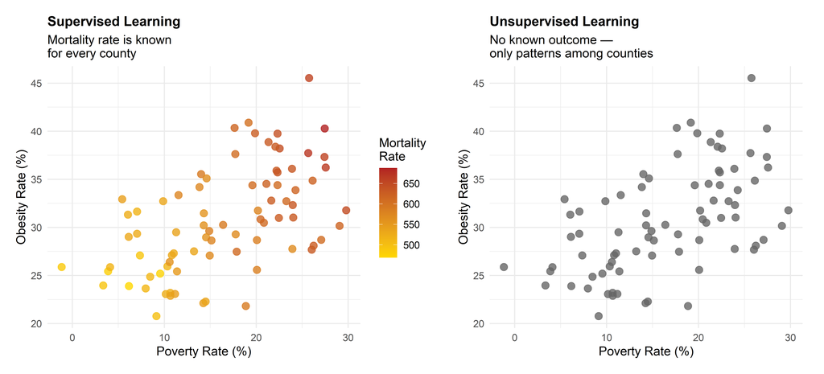

```r
set.seed(88)
n_demo <- 80

# Simulate two underlying "true" county health profiles for illustration
profile <- sample(c("A", "B"), n_demo, replace = TRUE)
poverty_demo <- ifelse(profile == "A", rnorm(n_demo, 22, 4), rnorm(n_demo, 10, 4))
obesity_demo <- ifelse(profile == "A", rnorm(n_demo, 34, 4), rnorm(n_demo, 26, 4))
mortality_demo <- 400 + 5 * poverty_demo + 3 * obesity_demo + rnorm(n_demo, 0, 15)

demo_df <- data.frame(poverty = poverty_demo, obesity = obesity_demo,
                       mortality = mortality_demo, profile = profile)

# Supervised view: predictors colored by the known outcome (mortality)
p_supervised <- ggplot(demo_df, aes(x = poverty, y = obesity, color = mortality)) +
  geom_point(size = 3, alpha = 0.8) +
  scale_color_gradient(low = "gold", high = "firebrick", name = "Mortality\nRate") +
  labs(title = "Supervised Learning",
       subtitle = "Mortality rate is known\nfor every county",
       x = "Poverty Rate (%)", y = "Obesity Rate (%)") +
  theme_minimal(base_size = 12) +
  theme(plot.title = element_text(face = "bold", size = 13),
        plot.margin = ggplot2::margin(10, 15, 10, 10))

# Unsupervised view: same predictors, no outcome shown, just raw points
p_unsupervised <- ggplot(demo_df, aes(x = poverty, y = obesity)) +
  geom_point(size = 3, alpha = 0.8, color = "gray40") +
  labs(title = "Unsupervised Learning",
       subtitle = "No known outcome —\nonly patterns among counties",
       x = "Poverty Rate (%)", y = "Obesity Rate (%)") +
  theme_minimal(base_size = 12) +
  theme(plot.title = element_text(face = "bold", size = 13),
        plot.margin = ggplot2::margin(10, 15, 10, 10))

p_supervised + p_unsupervised
```

Look at the two panels above. They show the *exact same* 80 counties, plotted on the same two axes (poverty rate and obesity rate). The only difference is what information we’re allowed to use:

- **Left (supervised)**: each county is colored by its actual mortality rate (gold = low, red = high). The algorithm’s job is to learn the relationship between the x/y position and that color, so it can predict the color (mortality rate) for a brand-new county.
- **Right (unsupervised)**: the color is hidden — we’ve stripped away the outcome entirely. All the algorithm can do is notice that the points seem to fall into two loose clusters based on their position alone. It has no way of knowing whether those clusters mean anything about mortality; it’s just describing structure in the predictors themselves.

#### 1-2. Why This Distinction Matters Before You Choose a Method

Every method we’ll walk through in the rest of this post — and the next one — sits cleanly in one of these two buckets:

|  | Supervised | Unsupervised |
| --- | --- | --- |
| **Has a “right answer” during training?** | Yes | No |
| **Typical question** | “Predict Y from X” | “Find hidden structure in X” |
| **Examples** | Lasso, ridge, elastic net, decision trees, random forests, logistic regression, k-NN | Cluster analysis, principal component analysis, topic modeling |
| **How you check if it worked** | Compare predictions to the true, known outcome | Judge whether the discovered groups make substantive or statistical sense (no ground truth to check against) |

The rest of this post — bias-variance and regularization — all lives inside the **supervised** bucket, because lasso, ridge, and elastic net are all methods for predicting a known outcome (mortality rate) from a set of predictors. Unsupervised methods raise a different set of questions entirely — mainly, “how do we know the patterns we found are real, and not just noise?” — which we’ll return to in a later post.

### 2. The Bias-Variance Tradeoff and Generalization Error

#### 2-1. Why a Model That Fits Well Can Still Predict Badly

Here’s a puzzle that trips up a lot of researchers the first time they see it: a model can fit your existing data almost perfectly and still make *terrible* predictions on new data. Understanding why requires breaking prediction error into two separate pieces: **bias** and **variance**.

**Bias** is the error from a model that’s too simple to capture the real pattern. Think of a clock that always runs an hour late — every reading is wrong in the same, predictable direction. A straight line fit to a curved relationship has bias: it will systematically miss the curve.

**Variance** is the error from a model that’s *too* sensitive to the specific data it happened to see. Think of a clock that randomly runs fast or slow — you can’t predict which way it will be wrong next time. A model with high variance would look completely different if you gave it a slightly different sample of the same population.

$$\text{Generalization Error} = \text{Bias}^2 + \text{Variance} + \text{Irreducible Error}$$

The irreducible error is just noise in the world that no model can ever remove — measurement error, unpredictable individual circumstances, and so on.

#### 2-2. Underfitting and Overfitting

- **Underfitting** happens when the model is too simple: it misses real signal in the data. High bias, low variance.
- **Overfitting** happens when the model is too complex: it captures not just the signal, but also the random noise specific to *this* sample. Low bias, high variance.

Now let’s make this concrete with our county data. Suppose the true relationship between income and mortality has a slight curve to it, but we don’t know that — we only have a sample of counties to learn from.

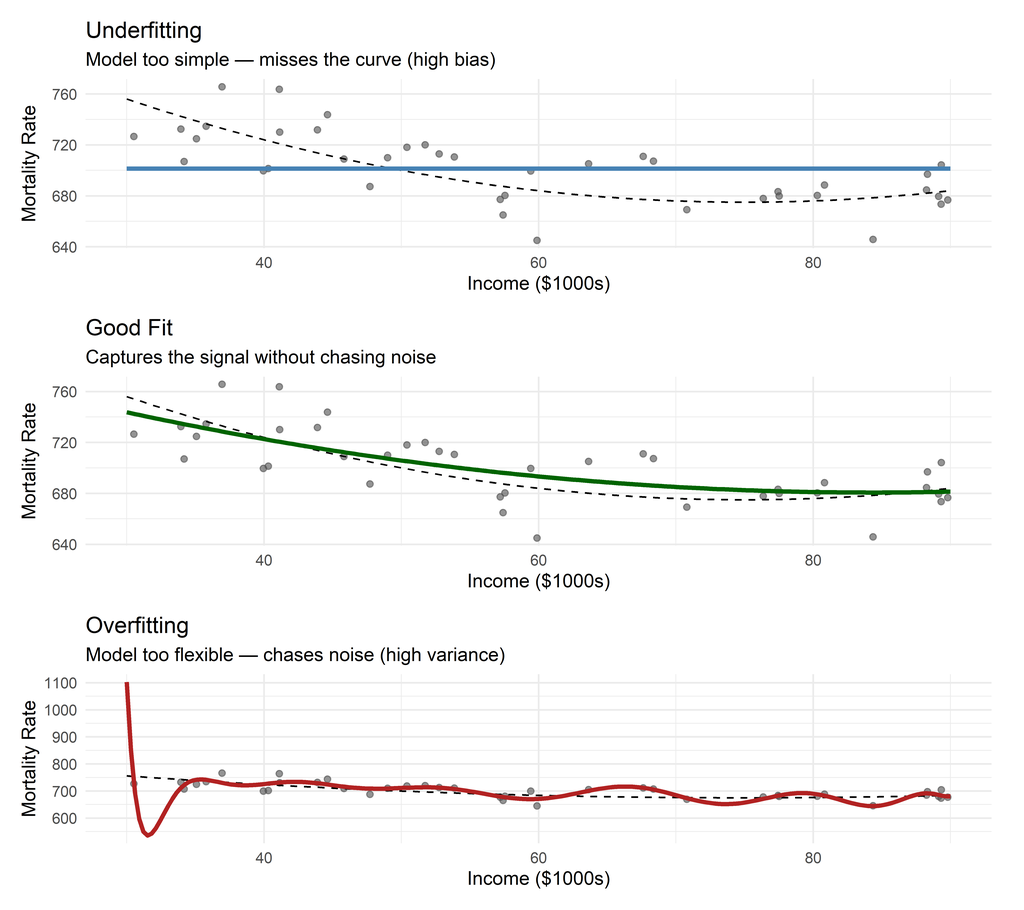

```r
set.seed(7)

# True underlying function (unknown to the researcher in practice)
true_function <- function(x) 900 - 6 * x + 0.04 * x^2

# Generate one sample
n_sample <- 40
x_sample <- runif(n_sample, 30, 90)
y_sample <- true_function(x_sample) + rnorm(n_sample, 0, 25)
sample_df <- data.frame(income = x_sample, mortality = y_sample)

x_grid <- seq(30, 90, length.out = 200)
true_line <- data.frame(income = x_grid, mortality = true_function(x_grid))

# Underfit: a flat model (intercept only)
underfit_pred <- data.frame(income = x_grid, mortality = mean(y_sample))

# Good fit: quadratic model (matches the true functional form)
good_fit <- lm(mortality ~ poly(income, 2), data = sample_df)
goodfit_pred <- data.frame(income = x_grid,
                            mortality = predict(good_fit, newdata = data.frame(income = x_grid)))

# Overfit: a very high-degree polynomial that chases every point
overfit_model <- lm(mortality ~ poly(income, 15), data = sample_df)
overfit_pred <- data.frame(income = x_grid,
                            mortality = predict(overfit_model, newdata = data.frame(income = x_grid)))

p_under <- ggplot() +
  geom_point(data = sample_df, aes(income, mortality), alpha = 0.6, color = "gray30") +
  geom_line(data = true_line, aes(income, mortality), color = "black", linetype = "dashed") +
  geom_line(data = underfit_pred, aes(income, mortality), color = "steelblue", linewidth = 1.3) +
  labs(title = "Underfitting", subtitle = "Model too simple — misses the curve (high bias)",
       x = "Income ($1000s)", y = "Mortality Rate") +
  theme_minimal(base_size = 12) +
  theme(plot.margin = ggplot2::margin(8, 15, 8, 8))

p_good <- ggplot() +
  geom_point(data = sample_df, aes(income, mortality), alpha = 0.6, color = "gray30") +
  geom_line(data = true_line, aes(income, mortality), color = "black", linetype = "dashed") +
  geom_line(data = goodfit_pred, aes(income, mortality), color = "darkgreen", linewidth = 1.3) +
  labs(title = "Good Fit", subtitle = "Captures the signal without chasing noise",
       x = "Income ($1000s)", y = "Mortality Rate") +
  theme_minimal(base_size = 12) +
  theme(plot.margin = ggplot2::margin(8, 15, 8, 8))

p_over <- ggplot() +
  geom_point(data = sample_df, aes(income, mortality), alpha = 0.6, color = "gray30") +
  geom_line(data = true_line, aes(income, mortality), color = "black", linetype = "dashed") +
  geom_line(data = overfit_pred, aes(income, mortality), color = "firebrick", linewidth = 1.3) +
  labs(title = "Overfitting", subtitle = "Model too flexible — chases noise (high variance)",
       x = "Income ($1000s)", y = "Mortality Rate") +
  theme_minimal(base_size = 12) +
  theme(plot.margin = ggplot2::margin(8, 15, 8, 8))

p_under / p_good / p_over
```

The dashed black line is the *true* relationship (which we’d never actually know in real research — it’s shown here only because this is a simulation). Notice:

- **Underfitting (top)**: the flat blue line ignores the curve entirely. It will be wrong in the same direction for every new county with low or high income.
- **Good fit (middle)**: the green curve tracks the true pattern closely without overreacting to any single point.
- **Overfitting (bottom)**: the red line wiggles wildly to pass as close as possible to every single training point — including the random noise. This model would look completely different if we resampled 40 new counties.

#### 2-3. Seeing It Numerically: In-Sample vs. Out-of-Sample Error

The real danger of overfitting is invisible if you only look at how well a model fits the data it was trained on. You have to test it on *new* data to see the problem.

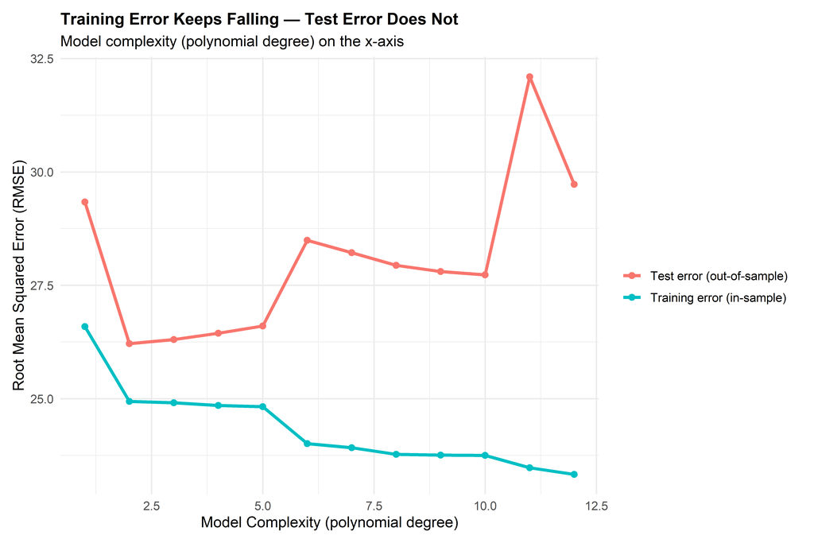

```r
set.seed(101)

# Generate training data and a separate, fresh test set from the same true process
train_x <- runif(60, 30, 90)
train_y <- true_function(train_x) + rnorm(60, 0, 25)
train_df <- data.frame(income = train_x, mortality = train_y)

test_x <- runif(60, 30, 90)
test_y <- true_function(test_x) + rnorm(60, 0, 25)
test_df <- data.frame(income = test_x, mortality = test_y)

# Fit models of increasing flexibility (polynomial degree = complexity)
degrees <- 1:12
results <- data.frame()

for (d in degrees) {
  model <- lm(mortality ~ poly(income, d), data = train_df)
  train_pred <- predict(model)
  test_pred <- predict(model, newdata = test_df)

  train_rmse <- sqrt(mean((train_df$mortality - train_pred)^2))
  test_rmse <- sqrt(mean((test_df$mortality - test_pred)^2))

  results <- rbind(results, data.frame(degree = d,
                                        train_rmse = train_rmse,
                                        test_rmse = test_rmse))
}

results_long <- results %>%
  pivot_longer(cols = c(train_rmse, test_rmse), names_to = "type", values_to = "rmse") %>%
  mutate(type = ifelse(type == "train_rmse", "Training error (in-sample)", "Test error (out-of-sample)"))

ggplot(results_long, aes(x = degree, y = rmse, color = type)) +
  geom_line(linewidth = 1.2) +
  geom_point(size = 2) +
  labs(title = "Training Error Keeps Falling — Test Error Does Not",
       subtitle = "Model complexity (polynomial degree) on the x-axis",
       x = "Model Complexity (polynomial degree)",
       y = "Root Mean Squared Error (RMSE)",
       color = "") +
  theme_minimal(base_size = 12) +
  theme(legend.position = "right",
        plot.title = element_text(face = "bold", size = 13),
        plot.margin = ggplot2::margin(10, 15, 10, 10))
```

This is one of the most important pictures in this post. It shows what happens as we make a model more and more complex (by raising the polynomial degree).

**How the experiment works**: We split the data into two separate groups.

We then make the model more and more complex — degree 1, degree 2, degree 3, and so on — and watch how the error (RMSE) changes on each of the two datasets.

**What we observe**:

- **Training error keeps shrinking.** As the model gets more complex, it can always fit the data it has already seen more closely — like memorizing the answers to a test you’ve already taken, getting closer and closer to a perfect score.
- **Test error falls at first, then turns around and starts rising again.** At first, added complexity helps the model capture more of the real underlying pattern (the “signal”). But past a certain point, the model starts memorizing the random noise mixed into the training data. That noise doesn’t repeat in a new county’s data, so from that point on, predictions on new data actually get worse.

**That turning point is the key.** Before it, the model is learning real signal. After it, the model has started memorizing noise.

**Bottom line**: the goal of any good model — classical statistics or machine learning — is to land at the point where **test error** is lowest, not where training error is lowest. If you judge a model only by its training error, you can end up picking a model that looks great on paper but performs poorly on any new county it hasn’t already memorized.

#### 2-4. Why More Predictors Also Cause Overfitting

Everything above showed overfitting happening because a *single* relationship was allowed to bend too much — a high-degree polynomial. But overfitting has a second, equally common cause in social science research: simply having **too many predictors** relative to the number of observations.

**The intuition**: each predictor you add gives the regression line one more “knob” it’s free to turn. With enough knobs, the model can bend itself to match almost any pattern in the training data — including patterns that are just noise. In the most extreme case, if the number of predictors equals the number of observations, OLS can draw a line that passes through every single point exactly ($R^2 = 1$) — not because it found the truth, but because it ran out of room to be wrong.

This also shows up as **instability**, not just a suspiciously perfect fit. Think of it this way: with only a handful of predictors, each one has plenty of counties’ worth of varied evidence behind it, so its estimated effect stays fairly steady even if a few counties in the sample change. But as you add more and more predictors — especially ones that overlap with each other, like poverty rate and uninsured rate — that evidence gets stretched thinner and thinner across more coefficients. Each individual estimate now rests on a smaller, shakier slice of information, so a small change in which counties happen to be in the sample can swing it substantially. More predictors mean more chances for a few of them to look meaningfully related to the outcome purely by coincidence, and OLS has no way to tell that apart from a real signal — it just fits both equally.

Let’s see this directly. We’ll fix the sample size at 40 counties and only 2 real predictors, then keep adding irrelevant “noise” predictors one at a time and watch what happens to model fit.

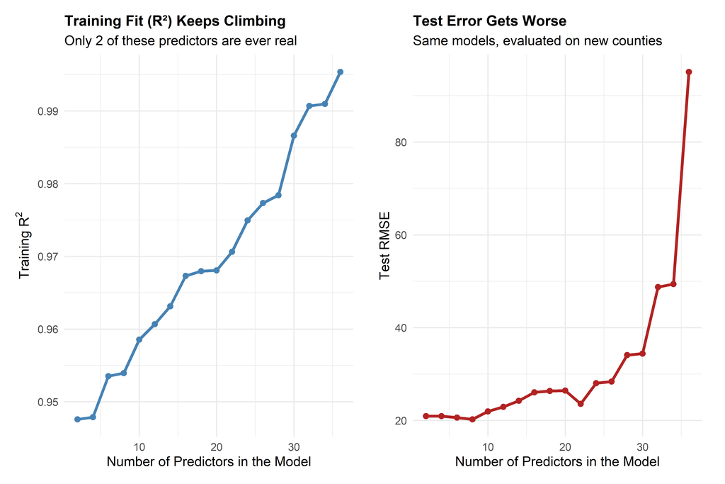

```r
set.seed(303)
n_fixed <- 40

# Two real predictors; everything else added below will be pure noise
x1 <- runif(n_fixed, 30, 90)
x2 <- runif(n_fixed, 0, 30)
true_y <- 500 + 5 * x1 - 3 * x2 + rnorm(n_fixed, 0, 20)

# A separate, fresh test set from the same true process
x1_test <- runif(n_fixed, 30, 90)
x2_test <- runif(n_fixed, 0, 30)
true_y_test <- 500 + 5 * x1_test - 3 * x2_test + rnorm(n_fixed, 0, 20)

max_noise <- 34
noise_train <- matrix(rnorm(n_fixed * max_noise), nrow = n_fixed)
noise_test <- matrix(rnorm(n_fixed * max_noise), nrow = n_fixed)

predictor_counts <- seq(2, 36, by = 2)
results_predictors <- data.frame()

for (p in predictor_counts) {
  n_noise <- p - 2
  if (n_noise == 0) {
    train_df_p <- data.frame(y = true_y, x1 = x1, x2 = x2)
    test_df_p <- data.frame(y = true_y_test, x1 = x1_test, x2 = x2_test)
  } else {
    train_df_p <- data.frame(y = true_y, x1 = x1, x2 = x2, noise_train[, 1:n_noise, drop = FALSE])
    test_df_p <- data.frame(y = true_y_test, x1 = x1_test, x2 = x2_test, noise_test[, 1:n_noise, drop = FALSE])
  }

  model_p <- lm(y ~ ., data = train_df_p)
  train_r2 <- summary(model_p)$r.squared
  test_pred_p <- predict(model_p, newdata = test_df_p)
  test_rmse_p <- sqrt(mean((test_df_p$y - test_pred_p)^2))

  results_predictors <- rbind(results_predictors,
                                data.frame(n_predictors = p, train_r2 = train_r2, test_rmse = test_rmse_p))
}

p_r2 <- ggplot(results_predictors, aes(x = n_predictors, y = train_r2)) +
  geom_line(color = "steelblue", linewidth = 1.2) +
  geom_point(size = 2, color = "steelblue") +
  labs(title = "Training Fit (R\u00b2) Keeps Climbing",
       subtitle = "Only 2 of these predictors are ever real",
       x = "Number of Predictors in the Model",
       y = expression("Training " * R^2)) +
  theme_minimal(base_size = 12) +
  theme(plot.title = element_text(face = "bold", size = 13),
        plot.margin = ggplot2::margin(8, 15, 8, 8))

p_rmse <- ggplot(results_predictors, aes(x = n_predictors, y = test_rmse)) +
  geom_line(color = "firebrick", linewidth = 1.2) +
  geom_point(size = 2, color = "firebrick") +
  labs(title = "Test Error Gets Worse",
       subtitle = "Same models, evaluated on new counties",
       x = "Number of Predictors in the Model",
       y = "Test RMSE") +
  theme_minimal(base_size = 12) +
  theme(plot.title = element_text(face = "bold", size = 13),
        plot.margin = ggplot2::margin(8, 15, 8, 8))

p_r2 + p_rmse
```

Same story as before, different knob. With only 2 real predictors driving mortality, adding more and more irrelevant noise variables pushes the training $R^2$ steadily toward 1 — the model looks like it’s “explaining” more and more of the data. But test error tells the opposite story: it climbs as the noise variables pile up, because each new one adds a coefficient that fits this training sample’s randomness and nothing more. By the time the model has 30+ predictors chasing a pattern built from just 2, it’s mostly memorizing noise.

This is exactly the situation many social science datasets create without anyone intending it — a long list of plausible-sounding control variables, most of which add more noise-fitting capacity than real explanatory power. It’s also exactly the problem regularization is built to solve.

### 3. The Principle of Regularization

#### 3-1. The Core Idea

Now we get to the tool that machine learning uses to avoid landing on the wrong side of that curve: **regularization**. The idea is simple to state: instead of only minimizing error on the training data, add a penalty for model complexity.

$$\underbrace{\sum_{i=1}^{n}[y_i - f(x_i)]^2}_{\text{fit to training data}} \;+\; \underbrace{\lambda R(f)}_{\text{penalty for complexity}}$$

- The first term is the same thing OLS already minimizes: how far off are our predictions?
- The second term, $\lambda R(f)$, punishes the model for being too flexible or having too-large coefficients.
- $\lambda$ (lambda) controls *how much* we care about that penalty. In ordinary OLS, $\lambda = 0$ — no penalty at all. As $\lambda$ increases, we push the model toward simplicity.

Choosing $\lambda$ is itself data-driven — it’s typically selected via cross-validation, so the model doesn’t just optimize the penalty by guesswork.

**What this trade actually buys us**: pushing coefficients toward zero introduces a small, deliberate **bias** — the estimates shift slightly away from their “true” values. In exchange, the model’s **variance** drops: its coefficients stop swinging wildly from sample to sample. Since total prediction error decomposes as $\text{Bias}^2 + \text{Variance}$, a small increase in bias can be more than offset by a large drop in variance — meaning the *total* error, and prediction accuracy on new data, actually improves. This trade tends to pay off most when predictors are numerous or highly correlated, exactly the setting where OLS’s variance is largest to begin with.

#### 3-2. Lasso, Ridge, and Elastic Net: Three Flavors of Penalty

The three primary regularized regression methods differ in how they define the penalty term $R(f)$: All three of these methods start from the exact same idea — penalize big coefficients — but they punish “bigness” in different ways, and that difference changes what the model does in practice.

Think of it like packing a suitcase with a strict weight limit. You have 30 items (our county-level predictors: poverty rate, opioid prescribing rate, racial composition, physician density, and so on) and a budget for how much “weight” your model’s coefficients are allowed to carry in total.

##### 3-2-1. Lasso ($L_1$ Penalty)

“Some items just don’t make the cut — leave them home entirely.” Lasso can shrink some coefficients all the way to *exactly* zero, which means those variables are dropped from the model completely. This gives you automatic variable selection: lasso tells you which handful of predictors actually matter.

$$\min_{\beta} \sum_{i=1}^{n} [y_i - f(x_i)]^2 \;+\; \lambda \sum_{j=1}^{p} \lvert\beta_j\rvert$$

- **Mechanism**: Punishes the sum of *absolute* values of coefficients.
- **Behavior**: The $L_1$ penalty retains a constant derivative down to zero, driving coefficients of non-essential variables to **exactly zero**. Performs automatic feature selection.

##### 3-2-2. Ridge Regression ($L_2$ Penalty)

“Every item can come, but the heavier ones get squeezed down more.” Ridge shrinks *every* coefficient toward zero, proportionally more for large ones, but essentially never sets a coefficient to exactly zero. Every variable stays in the model, just with a smaller voice.

$$\min_{\beta} \sum_{i=1}^{n} [y_i - f(x_i)]^2 \;+\; \lambda \sum_{j=1}^{p} \beta_j^2$$

- **Mechanism**: Punishes the sum of *squared* coefficients.
- **Behavior**: Shrinks all coefficients continuously toward zero, but **never sets any coefficient to exactly zero**. Every variable remains in the model.

##### 3-2-3. Elastic Net (Blended Penalty)

Compromise between the Lasso and Ridge: “Squeeze everything down, *and* leave some things home.” It combines both penalties, weighted by a parameter $\alpha$ between 0 and 1: $\alpha = 1$ is pure lasso, $\alpha = 0$ is pure ridge, and anything in between is elastic net.

$$\min_{\beta} \sum_{i=1}^{n} [y_i - f(x_i)]^2 \;+\; \lambda \left[ \alpha \sum_{j=1}^{p} \lvert\beta_j\rvert + (1-\alpha) \sum_{j=1}^{p} \beta_j^2 \right]$$

- **Mechanism**: Combines $L_1$ (Lasso) and $L_2$ (Ridge) penalties via weight parameter $\alpha \in [0, 1]$.
- **Behavior**: Provides sparse variable selection (via $L_1$) while maintaining stable coefficient grouping among correlated predictors (via $L_2$).

**Why would you ever want ridge instead of lasso, if lasso does variable selection for you?** Two practical reasons come up constantly in county health research:

1. **Correlated predictors.** County-level variables are often highly correlated with each other — for example, poverty rate, uninsured rate, and low education tend to move together. Lasso tends to arbitrarily pick just *one* of a group of correlated variables and zero out the rest, even if they’re all genuinely related to the outcome. Ridge instead spreads the credit across all of them, which can be more stable and realistic.
2. **You don’t actually want to drop variables.** Sometimes you have good theoretical reasons to keep every predictor in the model (e.g., you’re building a prediction tool that should always report physician density, even if its coefficient is small), and you just want to control overfitting without deleting anything. Ridge does exactly that.

**Elastic net** is often the practical default when you have many correlated county-level variables and also want some of them to drop out: it handles correlated groups better than lasso alone, while still allowing some coefficients to hit exactly zero.

#### 3-3. A Worked Example: Predicting County Mortality

To compare these methods empirically, we simulate a county health dataset with $n = 100$ counties and $p = 30$ candidate predictors. In the true underlying data-generating process, only the first 4 variables drive mortality ($\beta_1=8, \beta_2=-6, \beta_3=5, \beta_4=-4$), while the remaining 26 variables are pure noise ($\beta_{5\dots30} = 0$).

##### 3-3-1. Lasso in Action ($L_1$ Penalty)

We first fit Lasso ($\alpha = 1$) across a continuum of penalty values ($\lambda$):

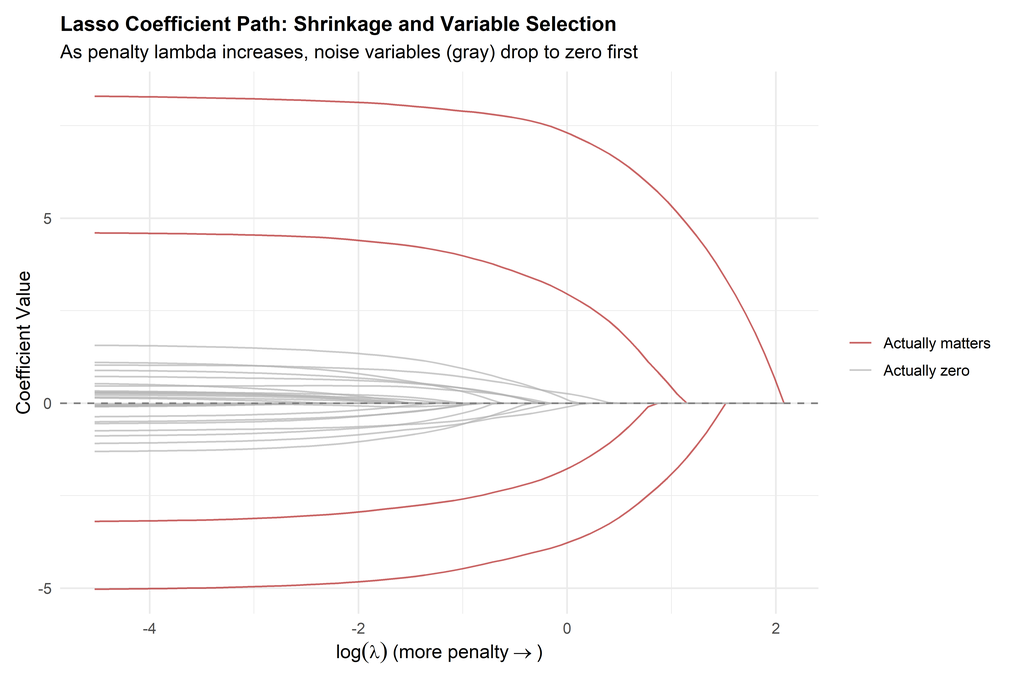

```r
set.seed(2024)
n_counties_sim <- 100
n_predictors <- 30  # 30 candidate variables

# Simulate predictors (standardized county-level variables)
X <- matrix(rnorm(n_counties_sim * n_predictors), nrow = n_counties_sim)
colnames(X) <- paste0("var", 1:n_predictors)

# Only the first 4 variables genuinely drive mortality
true_betas <- c(8, -6, 5, -4, rep(0, n_predictors - 4))
mortality_sim <- X %*% true_betas + rnorm(n_counties_sim, 0, 5)

# Fit lasso across a range of lambda values
lasso_fit <- glmnet(X, mortality_sim, alpha = 1)  # alpha = 1 is lasso

# Extract coefficient paths
coef_matrix <- as.matrix(coef(lasso_fit))[-1, ]  # remove intercept
coef_df <- as.data.frame(t(coef_matrix)) %>%
  mutate(lambda = lasso_fit$lambda) %>%
  pivot_longer(-lambda, names_to = "variable", values_to = "coefficient") %>%
  mutate(truly_matters = ifelse(variable %in% paste0("var", 1:4), "Actually matters", "Actually zero"))

ggplot(coef_df, aes(x = log(lambda), y = coefficient, group = variable, color = truly_matters)) +
  geom_line(alpha = 0.7) +
  geom_hline(yintercept = 0, linetype = "dashed", color = "gray50") +
  labs(title = "Lasso Coefficient Path: Shrinkage and Variable Selection",
       subtitle = "As penalty lambda increases, noise variables (gray) drop to zero first",
       x = expression(log(lambda) ~ "(more penalty" %->% ")"),
       y = "Coefficient Value",
       color = "") +
  scale_color_manual(values = c("Actually matters" = "firebrick", "Actually zero" = "gray70")) +
  theme_minimal(base_size = 12) +
  theme(legend.position = "right",
        plot.title = element_text(face = "bold", size = 13),
        plot.margin = ggplot2::margin(10, 15, 10, 10))
```

**Lasso Interpretation**: - At low $\lambda$ ($\log(\lambda)$ on left), all 30 variables have non-zero coefficients (similar to unpenalized OLS). - As $\lambda$ increases, the 26 noise variables (gray lines) drop to zero one by one. - The 4 true signals (red lines) resist shrinkage longer, demonstrating how Lasso isolates true drivers through **sparse variable selection**.

##### 3-3-2. Ridge in Action ($L_2$ Penalty)

Next, we fit Ridge Regression ($\alpha = 0$) on the exact same dataset:

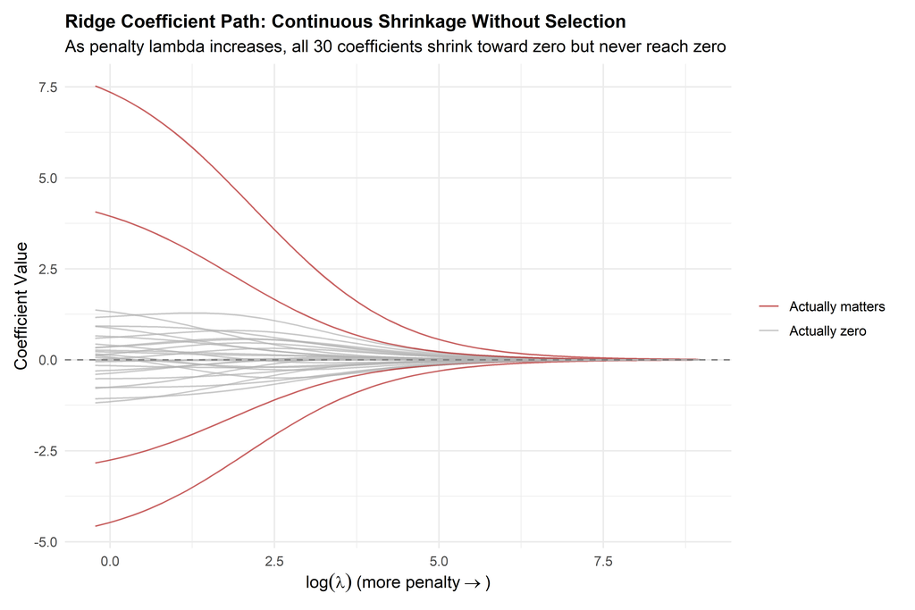

```r
# Fit ridge across a range of lambda values
ridge_fit <- glmnet(X, mortality_sim, alpha = 0)  # alpha = 0 is ridge

# Extract coefficient paths
ridge_coef_matrix <- as.matrix(coef(ridge_fit))[-1, ]
ridge_coef_df <- as.data.frame(t(ridge_coef_matrix)) %>%
  mutate(lambda = ridge_fit$lambda) %>%
  pivot_longer(-lambda, names_to = "variable", values_to = "coefficient") %>%
  mutate(truly_matters = ifelse(variable %in% paste0("var", 1:4), "Actually matters", "Actually zero"))

ggplot(ridge_coef_df, aes(x = log(lambda), y = coefficient, group = variable, color = truly_matters)) +
  geom_line(alpha = 0.7) +
  geom_hline(yintercept = 0, linetype = "dashed", color = "gray50") +
  labs(title = "Ridge Coefficient Path: Continuous Shrinkage Without Selection",
       subtitle = "As penalty lambda increases, all 30 coefficients shrink toward zero but never reach zero",
       x = expression(log(lambda) ~ "(more penalty" %->% ")"),
       y = "Coefficient Value",
       color = "") +
  scale_color_manual(values = c("Actually matters" = "firebrick", "Actually zero" = "gray70")) +
  theme_minimal(base_size = 12) +
  theme(legend.position = "right",
        plot.title = element_text(face = "bold", size = 13),
        plot.margin = ggplot2::margin(10, 15, 10, 10))
```

**Ridge Interpretation**: - As $\lambda$ increases, all 30 coefficients shrink smoothly toward zero. - Crucially, **none of the 26 noise variables hit zero exactly**. Every single variable remains in the model, regardless of how large $\lambda$ becomes.

##### 3-3-3. Lasso vs. Ridge, Side by Side

Placing Lasso ($\alpha = 1$) and Ridge ($\alpha = 0$) side by side on the exact same dataset highlights their fundamental structural difference:

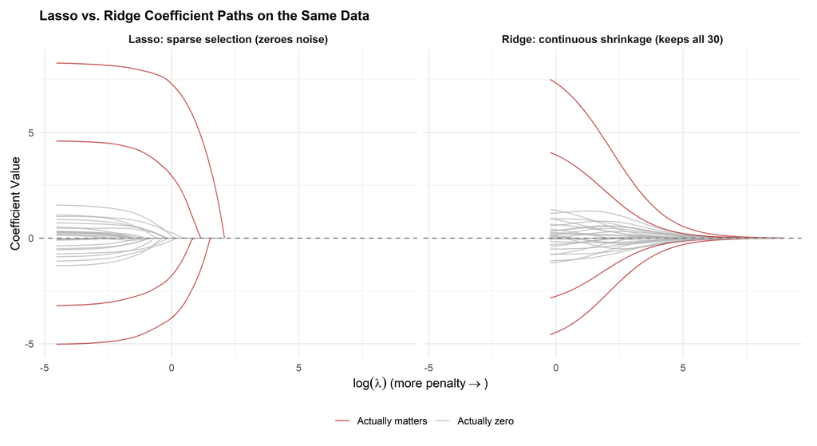

```r
lasso_coef_df_labeled <- coef_df %>%
  mutate(method = "Lasso: sparse selection (zeroes noise)")

ridge_coef_df_labeled <- ridge_coef_df %>%
  mutate(method = "Ridge: continuous shrinkage (keeps all 30)")

combined_df <- bind_rows(lasso_coef_df_labeled, ridge_coef_df_labeled)
combined_df$method <- factor(combined_df$method, levels = c("Lasso: sparse selection (zeroes noise)", "Ridge: continuous shrinkage (keeps all 30)"))

ggplot(combined_df, aes(x = log(lambda), y = coefficient, group = variable, color = truly_matters)) +
  geom_line(alpha = 0.7) +
  geom_hline(yintercept = 0, linetype = "dashed", color = "gray50") +
  facet_wrap(~method) +
  labs(title = "Lasso vs. Ridge Coefficient Paths on the Same Data",
       x = expression(log(lambda) ~ "(more penalty" %->% ")"),
       y = "Coefficient Value",
       color = "") +
  scale_color_manual(values = c("Actually matters" = "firebrick", "Actually zero" = "gray70")) +
  theme_minimal(base_size = 12) +
  theme(legend.position = "bottom",
        plot.title = element_text(face = "bold", size = 13),
        strip.text = element_text(face = "bold", size = 10.5),
        plot.margin = ggplot2::margin(10, 15, 10, 10))
```

**Key Differences Illustrated**:

- **Lasso (Left)**: Noise lines collapse directly onto the zero axis, performing **hard variable elimination** (setting 26 noise variables to exactly 0).
- **Ridge (Right)**: All 26 gray noise lines shrink continuously toward zero, but **none reach zero**. All 30 variables remain in the model.

##### 3-3-4. Choosing the Right Amount of Penalty: Cross-Validation

How do we choose $\lambda$? We don’t guess — we use $k$-fold cross-validation (`cv.glmnet()`) to find the penalty that minimizes out-of-sample prediction error. The data is split into $k$ folds; the model trains on $k-1$ folds and tests on the remaining fold, repeating until every fold serves as the test set once.

[figure not shown]

```r
set.seed(2024)
cv_lasso <- cv.glmnet(X, mortality_sim, alpha = 1)

par(mar = c(7, 4, 4, 2))
plot(cv_lasso)
title("Lasso: Cross-Validated Error by Lambda", line = 2.5)
mtext("Left dashed line: best prediction (lambda.min)", side = 1, line = 5, cex = 0.8)
mtext("Right dashed line: simplest good model (lambda.1se)", side = 1, line = 6, cex = 0.8)
```

[figure not shown]

```r
set.seed(2024)
cv_ridge <- cv.glmnet(X, mortality_sim, alpha = 0)

par(mar = c(7, 4, 4, 2))
plot(cv_ridge)
title("Ridge: Cross-Validated Error by Lambda", line = 2.5)
mtext("Left dashed line: best prediction (lambda.min)", side = 1, line = 5, cex = 0.8)
mtext("Right dashed line: simplest good model (lambda.1se)", side = 1, line = 6, cex = 0.8)
```

**Reading the CV curves**:

- The x-axis is $-\log(\lambda)$ (moving right reduces penalty toward OLS). The y-axis shows mean squared error on held-out folds.
- **Lasso** forms a classic U-shape: error drops as signal is captured, then rises as noise re-enters.
- **Ridge** error decreases continuously across this range as all 30 variables remain active throughout.

```r
cat("Lasso  — lambda.min:", round(cv_lasso$lambda.min, 3),
    " | lambda.1se:", round(cv_lasso$lambda.1se, 3), "\n")
```

```
Lasso  — lambda.min: 0.538  | lambda.1se: 0.94
```

```r
cat("Ridge  — lambda.min:", round(cv_ridge$lambda.min, 3),
    " | lambda.1se:", round(cv_ridge$lambda.1se, 3))
```

```
Ridge  — lambda.min: 0.799  | lambda.1se: 2.44
```

We evaluate two standard $\lambda$ thresholds: `lambda.min` (minimum CV error) and `lambda.1se` (the most parsimonious model within one standard error of the minimum).

```r
# Which variables survive at the cross-validation-selected lambda?
selected_coefs <- coef(cv_lasso, s = "lambda.min")
selected_df <- data.frame(
  variable = rownames(selected_coefs)[-1],
  coefficient = as.vector(selected_coefs)[-1]
) %>%
  filter(coefficient != 0) %>%
  arrange(desc(abs(coefficient)))

kable(selected_df, digits = 2,
      caption = "Variables Selected by Lasso at the Cross-Validation-Chosen Lambda") %>%
  kable_styling(bootstrap_options = c("striped", "hover", "condensed"))
```

Variables Selected by Lasso at the Cross-Validation-Chosen Lambda

| variable | coefficient |
| --- | --- |
| var1 | 7.77 |
| var2 | -4.24 |
| var3 | 3.67 |
| var4 | -2.35 |
| var15 | 0.67 |
| var27 | 0.56 |
| var28 | -0.37 |
| var9 | -0.29 |
| var7 | 0.24 |
| var5 | -0.24 |
| var10 | 0.23 |
| var16 | 0.23 |

At `lambda.min`, Lasso retains 12 of the 30 variables. Crucially, the 4 true drivers of mortality (`var1`–`var4`) emerge with by far the largest coefficients, while only 8 minor noise terms slip through.

In contrast, Ridge keeps all 30 variables in the model at its optimal `lambda.min`:

```r
# Ridge coefficients at its own cross-validation-chosen lambda
ridge_selected_coefs <- coef(cv_ridge, s = "lambda.min")
ridge_selected_df <- data.frame(
  variable = rownames(ridge_selected_coefs)[-1],
  coefficient = as.vector(ridge_selected_coefs)[-1]
) %>%
  arrange(desc(abs(coefficient)))

kable(head(ridge_selected_df, 30), digits = 3,
      caption = "Ridge Coefficients at Its Cross-Validation-Chosen Lambda (All 30 Variables)") %>%
  kable_styling(bootstrap_options = c("striped", "hover", "condensed"))
```

Ridge Coefficients at Its Cross-Validation-Chosen Lambda (All 30 Variables)

| variable | coefficient |
| --- | --- |
| var1 | 7.523 |
| var2 | -4.571 |
| var3 | 4.062 |
| var4 | -2.835 |
| var15 | 1.370 |
| var5 | -1.182 |
| var27 | 1.165 |
| var28 | -1.071 |
| var16 | 0.925 |
| var18 | 0.919 |
| var25 | -0.782 |
| var9 | -0.759 |
| var7 | 0.658 |
| var10 | 0.589 |
| var29 | -0.519 |
| var23 | 0.431 |
| var11 | -0.400 |
| var14 | 0.335 |
| var26 | 0.331 |
| var21 | -0.306 |
| var6 | 0.265 |
| var20 | 0.224 |
| var8 | 0.161 |
| var22 | -0.153 |
| var30 | 0.123 |
| var12 | 0.122 |
| var13 | 0.067 |
| var24 | -0.051 |
| var17 | -0.017 |
| var19 | 0.001 |

Ridge correctly ranks the 4 true predictors at the top, but shrinks all 30 coefficients continuously rather than performing variable selection.

##### 3-3-5. Elastic Net on the Same Data: Combining Ridge and Lasso

How does **Elastic Net** ($\alpha = 0.5$) differ from Lasso ($\alpha = 1$) and Ridge ($\alpha = 0$)?

Elastic Net blends both penalties: $\lambda [ \alpha \sum |\beta_j| + (1-\alpha) \sum \beta_j^2 ]$. This design addresses the core limitations of both methods:

1. **Unlike Ridge**, Elastic Net can set coefficients to *exactly zero*, dropping noise variables.
2. **Unlike Lasso**, Elastic Net handles *correlated predictors* stably without arbitrarily picking one and zeroing out the rest.

Let’s test Elastic Net on the exact same dataset (`X` and `mortality_sim`):

[figure not shown]

```r
set.seed(2024)
cv_enet <- cv.glmnet(X, mortality_sim, alpha = 0.5)

par(mar = c(7, 4, 4, 2))
plot(cv_enet)
title("Elastic Net (alpha = 0.5): Cross-Validated Error by Lambda", line = 2.5)
mtext("Left dashed line: best prediction (lambda.min)", side = 1, line = 5, cex = 0.8)
mtext("Right dashed line: simplest good model (lambda.1se)", side = 1, line = 6, cex = 0.8)
```

```r
cat("Ridge        — lambda.min:", round(cv_ridge$lambda.min, 3),
    " | lambda.1se:", round(cv_ridge$lambda.1se, 3), "\n")
```

```
Ridge        — lambda.min: 0.799  | lambda.1se: 2.44
```

```r
cat("Lasso        — lambda.min:", round(cv_lasso$lambda.min, 3),
    " | lambda.1se:", round(cv_lasso$lambda.1se, 3), "\n")
```

```
Lasso        — lambda.min: 0.538  | lambda.1se: 0.94
```

```r
cat("Elastic Net  — lambda.min:", round(cv_enet$lambda.min, 3),
    " | lambda.1se:", round(cv_enet$lambda.1se, 3))
```

```
Elastic Net  — lambda.min: 0.676  | lambda.1se: 1.561
```

Elastic Net’s optimal penalty (`lambda.min` = 0.676) falls directly between Ridge (0.799) and Lasso (0.538).

```r
# Which variables survive at elastic net's cross-validation-selected lambda?
enet_selected_coefs <- coef(cv_enet, s = "lambda.min")
enet_selected_df <- data.frame(
  variable = rownames(enet_selected_coefs)[-1],
  coefficient = as.vector(enet_selected_coefs)[-1]
) %>%
  filter(coefficient != 0) %>%
  arrange(desc(abs(coefficient)))

kable(enet_selected_df, digits = 2,
      caption = "Variables Selected by Elastic Net at the Cross-Validation-Chosen Lambda") %>%
  kable_styling(bootstrap_options = c("striped", "hover", "condensed"))
```

Variables Selected by Elastic Net at the Cross-Validation-Chosen Lambda

| variable | coefficient |
| --- | --- |
| var1 | 7.65 |
| var2 | -4.34 |
| var3 | 3.82 |
| var4 | -2.50 |
| var15 | 0.91 |
| var27 | 0.81 |
| var28 | -0.61 |
| var5 | -0.59 |
| var9 | -0.51 |
| var16 | 0.46 |
| var7 | 0.42 |
| var10 | 0.40 |
| var18 | 0.32 |
| var25 | -0.28 |
| var29 | -0.11 |
| var11 | -0.06 |
| var17 | -0.04 |

```r
cat("Number of nonzero coefficients (out of 30):\n")
```

```
Number of nonzero coefficients (out of 30):
```

```r
cat("  Ridge:      ", sum(coef(cv_ridge, s = "lambda.min")[-1] != 0), "\n")
```

```
  Ridge:       30
```

```r
cat("  Lasso:      ", sum(coef(cv_lasso, s = "lambda.min")[-1] != 0), "\n")
```

```
  Lasso:       12
```

```r
cat("  Elastic Net:", sum(coef(cv_enet, s = "lambda.min")[-1] != 0))
```

```
  Elastic Net: 17
```

**Comparing Variable Selection Behavior**:

- **Ridge (30/30 non-zero)**: No variable selection; retains every predictor.
- **Lasso (12/30 non-zero)**: Aggressive selection; zeroes out 18 noise variables.
- **Elastic Net (17/30 non-zero)**: Balanced selection; zeroes out 13 noise variables while offering smoother shrinkage for surviving predictors.

##### 3-3-6. Handling Correlated Predictors: A Direct Comparison

The key advantage of Elastic Net over Lasso becomes obvious when predictors are collinear (e.g., Poverty Rate and Uninsured Rate moving together across counties).

**Two ways to check “variance” here**: what we want to show is how much each method’s coefficients would swing across different samples. The correct way to check that is a **Monte Carlo simulation** — regenerate the dataset from scratch many times and see how much each method’s answer changes. But every other example in this post uses just one dataset, which is what you’d actually have in real research. So I’ll do both: first, a $k$-fold version that stays consistent with “one dataset only,” then the full Monte Carlo version, so we can see how much they agree.

###### 3-3-6-1. Version 1: k-Fold Cross-Validation on One Dataset

This uses only the single dataset below, split into 10 folds. Each fold trains on a different 90% of the counties, and comparing coefficients across folds gives a rough sense of how stable each method is — without ever generating new data.

```r
set.seed(55)

# Simulate two "true" predictors that are highly correlated with each other (r ≈ 0.8)
n_counties_sim <- 100
poverty_rate <- rnorm(n_counties_sim, 15, 5)
uninsured_rate_corr <- poverty_rate * 0.8 + rnorm(n_counties_sim, 0, 1.5)

# Both contribute equally to mortality (true effect = 3.0 each)
mortality_corr <- 500 + 3 * poverty_rate + 3 * uninsured_rate_corr + rnorm(n_counties_sim, 0, 10)

X_corr <- cbind(poverty_rate, uninsured_rate_corr,
                 matrix(rnorm(n_counties_sim * 8), nrow = n_counties_sim))
colnames(X_corr) <- c("poverty_rate", "uninsured_rate", paste0("noise", 1:8))

# Single-sample estimates for OLS, Ridge, Lasso, and Elastic Net (full dataset)
df_corr <- as.data.frame(X_corr)
df_corr$mortality <- mortality_corr
ols_fit <- lm(mortality ~ ., data = df_corr)
ols_result <- coef(ols_fit)[c("poverty_rate", "uninsured_rate")]

cv_ridge_corr <- cv.glmnet(X_corr, mortality_corr, alpha = 0)
cv_lasso_corr <- cv.glmnet(X_corr, mortality_corr, alpha = 1)
cv_enet_corr <- cv.glmnet(X_corr, mortality_corr, alpha = 0.5)

ridge_result <- coef(cv_ridge_corr, s = "lambda.min")[c("poverty_rate", "uninsured_rate"), ]
lasso_result <- coef(cv_lasso_corr, s = "lambda.min")[c("poverty_rate", "uninsured_rate"), ]
enet_result <- coef(cv_enet_corr, s = "lambda.min")[c("poverty_rate", "uninsured_rate"), ]

# k-fold check: refit each method on each of k folds of THIS SAME dataset
k <- 10
set.seed(2024)
fold_id <- sample(rep(1:k, length.out = n_counties_sim))

res_ols_fold   <- matrix(0, k, 2)
res_ridge_fold <- matrix(0, k, 2)
res_lasso_fold <- matrix(0, k, 2)
res_enet_fold  <- matrix(0, k, 2)

for (i in 1:k) {
  train_idx <- which(fold_id != i)
  X_train <- X_corr[train_idx, ]
  y_train <- mortality_corr[train_idx]
  df_train <- as.data.frame(X_train)
  df_train$mortality <- y_train

  res_ols_fold[i, ] <- coef(lm(mortality ~ ., data = df_train))[c("poverty_rate", "uninsured_rate")]

  cv_r <- cv.glmnet(X_train, y_train, alpha = 0)
  cv_l <- cv.glmnet(X_train, y_train, alpha = 1)
  cv_e <- cv.glmnet(X_train, y_train, alpha = 0.5)

  res_ridge_fold[i, ] <- coef(cv_r, s = "lambda.min")[c("poverty_rate", "uninsured_rate"), ]
  res_lasso_fold[i, ] <- coef(cv_l, s = "lambda.min")[c("poverty_rate", "uninsured_rate"), ]
  res_enet_fold[i, ]  <- coef(cv_e, s = "lambda.min")[c("poverty_rate", "uninsured_rate"), ]
}

true_b <- c(3, 3)
b_ols_k   <- mean(abs(colMeans(res_ols_fold) - true_b))
v_ols_k   <- mean(apply(res_ols_fold, 2, var))
b_ridge_k <- mean(abs(colMeans(res_ridge_fold) - true_b))
v_ridge_k <- mean(apply(res_ridge_fold, 2, var))
b_lasso_k <- mean(abs(colMeans(res_lasso_fold) - true_b))
v_lasso_k <- mean(apply(res_lasso_fold, 2, var))
b_enet_k  <- mean(abs(colMeans(res_enet_fold) - true_b))
v_enet_k  <- mean(apply(res_enet_fold, 2, var))
```

```r
kfold_summary_df <- data.frame(
  Method = c("OLS", "Ridge", "Lasso", "Elastic Net"),
  `Abs Bias` = round(c(b_ols_k, b_ridge_k, b_lasso_k, b_enet_k), 3),
  `Variance` = round(c(v_ols_k, v_ridge_k, v_lasso_k, v_enet_k), 3),
  `MSE` = round(c(b_ols_k^2 + v_ols_k, b_ridge_k^2 + v_ridge_k,
                   b_lasso_k^2 + v_lasso_k, b_enet_k^2 + v_enet_k), 3),
  check.names = FALSE
)

kable(kfold_summary_df, caption = "Bias, Variance, and MSE from 10-Fold Cross-Validation (One Dataset)") %>%
  kable_styling(bootstrap_options = c("striped", "hover", "condensed"))
```

Bias, Variance, and MSE from 10-Fold Cross-Validation (One Dataset)

| Method | Abs Bias | Variance | MSE |
| --- | --- | --- | --- |
| OLS | 0.208 | 0.063 | 0.106 |
| Ridge | 0.329 | 0.018 | 0.127 |
| Lasso | 0.428 | 0.079 | 0.262 |
| Elastic Net | 0.369 | 0.033 | 0.169 |

Ridge has the lowest variance here, as expected. But its bias is large enough that its MSE ends up close to — or even slightly worse than — OLS’s. Lasso looks like the worst option on every measure. This is a useful first read, but with only 10 folds that overlap heavily with each other, it’s a fairly noisy estimate. Let’s check it against the “real” answer.

###### 3-3-6-2. Version 2: Monte Carlo Simulation (100 Fresh Datasets)

This time, instead of splitting one dataset into folds, I generate 100 completely new datasets from scratch and refit every method on each one. This is the textbook-correct way to measure variance — just not something you could ever do with real data, since real data only comes once.

```r
B <- 100
res_ols <- matrix(0, B, 2)
res_ridge <- matrix(0, B, 2)
res_lasso <- matrix(0, B, 2)
res_enet <- matrix(0, B, 2)

for (i in 1:B) {
  p_rate <- rnorm(n_counties_sim, 15, 5)
  u_rate <- p_rate * 0.8 + rnorm(n_counties_sim, 0, 1.5)
  m_rate <- 500 + 3 * p_rate + 3 * u_rate + rnorm(n_counties_sim, 0, 10)
  Xc <- cbind(p_rate, u_rate, matrix(rnorm(n_counties_sim * 8), nrow = n_counties_sim))
  colnames(Xc) <- c("p_rate", "u_rate", paste0("noise", 1:8))
  df_i <- as.data.frame(Xc)
  df_i$m_rate <- m_rate

  res_ols[i, ] <- coef(lm(m_rate ~ ., data = df_i))[c("p_rate", "u_rate")]

  cv_r <- cv.glmnet(Xc, m_rate, alpha = 0)
  cv_l <- cv.glmnet(Xc, m_rate, alpha = 1)
  cv_e <- cv.glmnet(Xc, m_rate, alpha = 0.5)

  res_ridge[i, ] <- coef(cv_r, s = "lambda.min")[c("p_rate", "u_rate"), ]
  res_lasso[i, ] <- coef(cv_l, s = "lambda.min")[c("p_rate", "u_rate"), ]
  res_enet[i, ]  <- coef(cv_e, s = "lambda.min")[c("p_rate", "u_rate"), ]
}

b_ols   <- mean(abs(colMeans(res_ols) - true_b))
v_ols   <- mean(apply(res_ols, 2, var))
b_ridge <- mean(abs(colMeans(res_ridge) - true_b))
v_ridge <- mean(apply(res_ridge, 2, var))
b_lasso <- mean(abs(colMeans(res_lasso) - true_b))
v_lasso <- mean(apply(res_lasso, 2, var))
b_enet  <- mean(abs(colMeans(res_enet) - true_b))
v_enet  <- mean(apply(res_enet, 2, var))
```

```r
mc_summary_df <- data.frame(
  Method = c("OLS", "Ridge", "Lasso", "Elastic Net"),
  `Abs Bias` = round(c(b_ols, b_ridge, b_lasso, b_enet), 3),
  `Variance` = round(c(v_ols, v_ridge, v_lasso, v_enet), 3),
  `MSE` = round(c(b_ols^2 + v_ols, b_ridge^2 + v_ridge,
                   b_lasso^2 + v_lasso, b_enet^2 + v_enet), 3),
  check.names = FALSE
)

kable(mc_summary_df, caption = "Bias, Variance, and MSE from 100 Independently Simulated Datasets") %>%
  kable_styling(bootstrap_options = c("striped", "hover", "condensed"))
```

Bias, Variance, and MSE from 100 Independently Simulated Datasets

| Method | Abs Bias | Variance | MSE |
| --- | --- | --- | --- |
| OLS | 0.039 | 0.465 | 0.466 |
| Ridge | 0.153 | 0.076 | 0.099 |
| Lasso | 0.136 | 0.448 | 0.467 |
| Elastic Net | 0.151 | 0.218 | 0.241 |

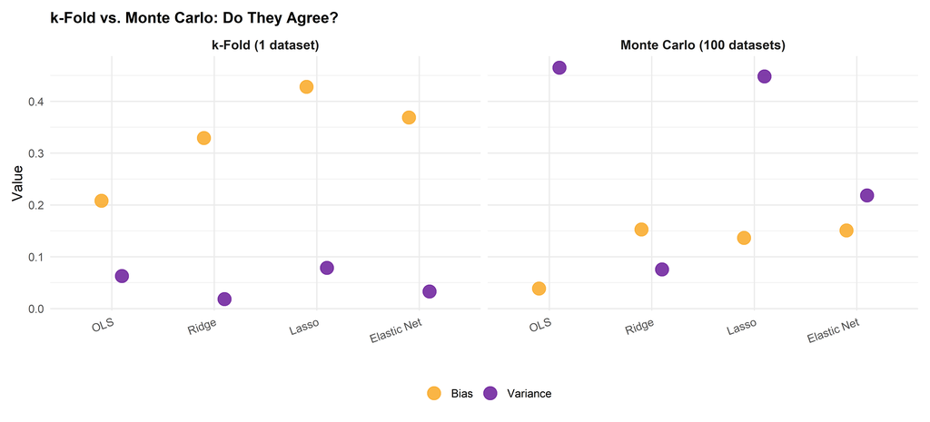

```r
compare_df <- data.frame(
  Method = rep(c("OLS", "Ridge", "Lasso", "Elastic Net"), times = 4),
  Metric = rep(c("Bias", "Variance"), each = 4, times = 2),
  Value = c(b_ols_k, b_ridge_k, b_lasso_k, b_enet_k,
            v_ols_k, v_ridge_k, v_lasso_k, v_enet_k,
            b_ols, b_ridge, b_lasso, b_enet,
            v_ols, v_ridge, v_lasso, v_enet),
  Approach = rep(c("k-Fold (1 dataset)", "Monte Carlo (100 datasets)"), each = 8)
)
compare_df$Method <- factor(compare_df$Method, levels = c("OLS", "Ridge", "Lasso", "Elastic Net"))

ggplot(compare_df, aes(x = Method, y = Value, color = Metric)) +
  geom_point(size = 5, alpha = 0.85, position = position_dodge(width = 0.4)) +
  scale_color_manual(values = c("Bias" = "#f9a825", "Variance" = "#6a1b9a")) +
  facet_wrap(~Approach) +
  labs(title = "k-Fold vs. Monte Carlo: Do They Agree?",
       x = "", y = "Value", color = "") +
  theme_minimal(base_size = 12) +
  theme(legend.position = "bottom",
        plot.title = element_text(face = "bold", size = 13),
        strip.text = element_text(face = "bold", size = 11),
        axis.text.x = element_text(angle = 20, hjust = 1),
        plot.margin = ggplot2::margin(10, 10, 10, 10))
```

#### 3-4. Why This Matters for Applied Research

When working with high-dimensional observational data (e.g., county health indicators), which method to reach for depends on what your predictors look like:

| Situation | Reach for | Why |
| --- | --- | --- |
| Many independent predictors; expect only a few really matter | **Lasso** | Cleanly drops the irrelevant ones |
| Predictors are highly correlated; want to keep every variable | **Ridge** | Splits credit evenly, never drops anyone |
| Many correlated predictors; still want some to drop out | **Elastic Net** | A middle path between the two |

**One important caution**: every regularized coefficient here is intentionally shrunk toward zero — that’s the whole point, and it’s what buys the drop in variance. But it also means these coefficients aren’t unbiased estimates of a “true” causal effect anymore. They’re excellent for prediction and for narrowing down a long list of candidate variables. If your actual goal is a trustworthy causal estimate — a number you’d report as “the effect of X” — the better workflow is to use lasso or elastic net just to *select* which control variables belong in the model, then re-estimate that shorter list with a standard, unpenalized method (like the fixed and random effects models covered in an earlier post in this series).

### 4. Conclusion

Supervised regularization links three core concepts into a cohesive workflow:

1. **Supervised Framework**: Learning from labeled outcomes ($Y$) to predict new data.
2. **Bias-Variance Tradeoff**: Balancing model capacity to avoid overfitting training noise — whether that flexibility comes from a curve that bends too much, or simply from having too many predictors.
3. **Regularization**: Using $\lambda$ penalties (Ridge, Lasso, Elastic Net) to control complexity systematically.

In the next post, we will explore **tree-based methods** (Decision Trees, Random Forests, Gradient Boosting) to see how non-linear complexity and variance reduction operate in non-parametric models.